# Exploring the Ford GoBike System Data for San Francisco and Comparing with Mobi Bike Data for Vancouver

## by Amir Khanlou

- Introduction
- Gatherin Data
- Assessing Data
- Cleaning Data
- Storing Data
- Visualizing Data
  - Univariate Exploration
  - Bivariate Exploration
  - Multivariate Exploration

## Introduction

> In this study, we are looking into analysing bike sharing data. The data sets include information about individual rides made in Ford GoBike bike-sharing system covering the greater San Francisco Bay area as well as Mobibikes system covering Vancouver, BC area. The purpose of this study is to answer some general questions about the bike sharing in these 2 cities and find out the user’s behaviour during 2019 to account for seasonal changes. Year 2020 turned out to be an unusual year with COVID-19 pandemic happening and there is anecdotal information that bike riding in general increased because of the pandemic. It would be interesting to investigate this via the data available for 2020 given the data only accounts for the first 4 months of 2020. It should be noted that this data represents the bike sharing usage and the ultimate results may not be representative of the actual overall biking behaviour since the bike users may tend to avoid using shared equipment due to concern over infection and instead utilize personal bikes. Nevertheless, we look into this in hope to find some insight

```python
# import all packages and set plots to be embedded inline
import numpy as np
import pandas as pd
import matplotlib.pyplot as plt
import seaborn as sb
import datetime
from os import listdir

%matplotlib inline
```

## Gathering Data

> - The data for San Francisco is downloaded from: https://www.lyft.com/bikes/bay-wheels/system-data
> - The data for Vancouver is downloaded from: https://www.mobibikes.ca/en/system-data

```python
filepaths = ['./sanfrancisco_data/' + f for f in listdir("./sanfrancisco_data") if f.endswith('.csv')]
#df_san = pd.concat(map(pd.read_csv, filepaths))

df_san = []
for f in filepaths:
    df_san.append(pd.read_csv(f))
```

```python
filepaths = ['./vancouver_data/' + f for f in listdir("./vancouver_data") if f.endswith('.csv')]

df_van = []
for f in filepaths:
    df_van.append(pd.read_csv(f))
```

## Assessing Data

```python
# Let's look at the columns of all 16 dataframes for San Francisco
sh = 0
for i in df_san:
    print(i.columns)
    sh+=i.shape[0]
    print(i.shape[0])
print(sh)
```

```
Index(['duration_sec', 'start_time', 'end_time', 'start_station_id',
       'start_station_name', 'start_station_latitude',
       'start_station_longitude', 'end_station_id', 'end_station_name',
       'end_station_latitude', 'end_station_longitude', 'bike_id', 'user_type',
       'bike_share_for_all_trip'],
      dtype='object')
192082
Index(['duration_sec', 'start_time', 'end_time', 'start_station_id',
       'start_station_name', 'start_station_latitude',
       'start_station_longitude', 'end_station_id', 'end_station_name',
       'end_station_latitude', 'end_station_longitude', 'bike_id', 'user_type',
       'bike_share_for_all_trip'],
      dtype='object')
183412
Index(['duration_sec', 'start_time', 'end_time', 'start_station_id',
       'start_station_name', 'start_station_latitude',
       'start_station_longitude', 'end_station_id', 'end_station_name',
       'end_station_latitude', 'end_station_longitude', 'bike_id', 'user_type',
       'bike_share_for_all_trip'],
      dtype='object')
256299
Index(['duration_sec', 'start_time', 'end_time', 'start_station_id',
       'start_station_name', 'start_station_latitude',
       'start_station_longitude', 'end_station_id', 'end_station_name',
       'end_station_latitude', 'end_station_longitude', 'bike_id', 'user_type',
       'bike_share_for_all_trip'],
      dtype='object')
239111
Index(['duration_sec', 'start_time', 'end_time', 'start_station_id',
       'start_station_name', 'start_station_latitude',
       'start_station_longitude', 'end_station_id', 'end_station_name',
       'end_station_latitude', 'end_station_longitude', 'bike_id', 'user_type',
       'bike_share_for_all_trip'],
      dtype='object')
182163
Index(['duration_sec', 'start_time', 'end_time', 'start_station_id',
       'start_station_name', 'start_station_latitude',
       'start_station_longitude', 'end_station_id', 'end_station_name',
       'end_station_latitude', 'end_station_longitude', 'bike_id', 'user_type',
       'bike_share_for_all_trip', 'rental_access_method'],
```

[output cut: 57 more lines]

```
432354
Index(['duration_sec', 'start_time', 'end_time', 'start_station_id',
       'start_station_name', 'start_station_latitude',
       'start_station_longitude', 'end_station_id', 'end_station_name',
       'end_station_latitude', 'end_station_longitude', 'bike_id', 'user_type',
       'rental_access_method'],
      dtype='object')
176799
Index(['ride_id', 'rideable_type', 'started_at', 'ended_at',
       'start_station_name', 'start_station_id', 'end_station_name',
       'end_station_id', 'start_lat', 'start_lng', 'end_lat', 'end_lng',
       'member_casual'],
      dtype='object')
84259
3496249
```

```python
# Cheking San Francisco data frame
df_san[0].head()
```

|  | duration_sec | start_time | end_time | start_station_id | start_station_name | start_station_latitude | start_station_longitude | end_station_id | end_station_name | end_station_latitude | end_station_longitude | bike_id | user_type | bike_share_for_all_trip |
| --- | --- | --- | --- | --- | --- | --- | --- | --- | --- | --- | --- | --- | --- | --- |
| 0 | 80825 | 2019-01-31 17:57:44.6130 | 2019-02-01 16:24:49.8640 | 229.0 | Foothill Blvd at 42nd Ave | 37.775745 | -122.213037 | 196.0 | Grand Ave at Perkins St | 37.808894 | -122.256460 | 4861 | Subscriber | No |
| 1 | 65900 | 2019-01-31 20:58:33.8860 | 2019-02-01 15:16:54.1730 | 4.0 | Cyril Magnin St at Ellis St | 37.785881 | -122.408915 | 134.0 | Valencia St at 24th St | 37.752428 | -122.420628 | 5506 | Subscriber | No |
| 2 | 62633 | 2019-01-31 18:06:52.9240 | 2019-02-01 11:30:46.5300 | 245.0 | Downtown Berkeley BART | 37.870139 | -122.268422 | 157.0 | 65th St at Hollis St | 37.846784 | -122.291376 | 2717 | Customer | No |
| 3 | 44680 | 2019-01-31 19:46:09.7190 | 2019-02-01 08:10:50.3180 | 85.0 | Church St at Duboce Ave | 37.770083 | -122.429156 | 53.0 | Grove St at Divisadero | 37.775946 | -122.437777 | 4557 | Customer | No |
| 4 | 60709 | 2019-01-31 14:19:01.5410 | 2019-02-01 07:10:51.0650 | 16.0 | Steuart St at Market St | 37.794130 | -122.394430 | 28.0 | The Embarcadero at Bryant St | 37.787168 | -122.388098 | 2100 | Customer | No |

It appears the last month (month of April) has a different structure which needs clean-up

```python
# Let's look at the columns of all 16 dataframes for Vancouver
sh = 0
for i in df_van:
    print(i.columns)
    sh+=i.shape[0]
    print(i.shape[0])
print(sh)
```

```
Index(['Departure', 'Return', 'Bike', 'Departure station', 'Return station',
       'Membership type', 'Covered distance (m)', 'Duration (sec.)',
       'Departure battery voltage (mV)', 'Return battery voltage (mV)',
       'Departure temperature (C)', 'Return temperature (C)',
       'Stopover duration', 'Number of stopovers', 'Manager'],
      dtype='object')
36750
Index(['Departure', 'Return', 'Bike', 'Departure station', 'Return station',
       'Membership Type', 'Covered distance (m)', 'Duration (sec.)',
       'Departure battery voltage (mV)', 'Return battery voltage (mV)',
       'Departure temperature (C)', 'Return temperature (C)',
       'Stopover duration', 'Number of stopovers'],
      dtype='object')
26103
Index(['Departure', 'Return', 'Bike', 'Departure station', 'Return station',
       'Membership type', 'Covered distance (m)', 'Duration (sec.)',
       'Departure battery voltage (mV)', 'Return battery voltage (mV)',
       'Departure temperature (C)', 'Return temperature (C)',
       'Stopover duration (sec.)', 'Number of stopovers', 'Manager'],
      dtype='object')
57459
Index(['Departure', 'Return', 'Bike', 'Departure station', 'Return station',
       'Membership type', 'Covered distance (m)', 'Duration (sec.)',
       'Departure battery voltage (mV)', 'Return battery voltage (mV)',
       'Departure temperature (C)', 'Return temperature (C)', 'Departure slot',
       'Return slot', 'Stopover duration (sec.)', 'Number of bike stopovers'],
      dtype='object')
58399
Index(['Departure', 'Return', 'Bike', 'Departure station', 'Return station',
       'Membership type', 'Covered distance (m)', 'Duration (sec.)',
       'Departure battery voltage (mV)', 'Return battery voltage (mV)',
       'Departure temperature (C)', 'Return temperature (C)',
       'Stopover duration (sec.)', 'Number of stopovers'],
      dtype='object')
94470
Index(['Departure', 'Return', 'Bike', 'Departure station', 'Return station',
       'Membership type', 'Covered distance (m)', 'Duration (sec.)',
       'Departure battery voltage (mV)', 'Return battery voltage (mV)',
       'Departure temperature (C)', 'Return temperature (C)',
       'Stopover duration (sec.)', 'Number of stopovers'],
```

[output cut: 57 more lines]

```
Index(['Departure', 'Return', 'Bike', 'Departure station', 'Return station',
       'Membership type', 'Covered distance (m)', 'Duration (sec.)',
       'Departure battery voltage (mV)', 'Return battery voltage (mV)',
       'Departure temperature (C)', 'Return temperature (C)',
       'Stopover duration (sec.)', 'Number of bike stopovers'],
      dtype='object')
36483
Index(['Departure', 'Return', 'Bike', 'Departure station', 'Return station',
       'Membership type', 'Covered distance (m)', 'Duration (sec.)',
       'Departure battery voltage (mV)', 'Return battery voltage (mV)',
       'Departure temperature (C)', 'Return temperature (C)',
       'Stopover duration (sec.)', 'Number of stopovers'],
      dtype='object')
30724
1025125
```

```python
# Checking Vancouver dataframe
df_van[0].head()
```

|  | Departure | Return | Bike | Departure station | Return station | Membership type | Covered distance (m) | Duration (sec.) | Departure battery voltage (mV) | Return battery voltage (mV) | Departure temperature (C) | Return temperature (C) | Stopover duration | Number of stopovers | Manager |
| --- | --- | --- | --- | --- | --- | --- | --- | --- | --- | --- | --- | --- | --- | --- | --- |
| 0 | 2/1/2019 0:00 | 2/1/2019 0:00 | 388.0 | 0198 6th & Main | 0298 6th & Carolina | 365 Standard | 714.0 | 177 | 3826 | 4000 | 9 | 9 | 0 | 0 | False |
| 1 | 2/1/2019 0:00 | 2/1/2019 0:00 | 1880.0 | 0193 Science World | 0173 1st & Columbia | 365 Plus | 859.0 | 221 | 3705 | 3850 | 9 | 11 | 0 | 0 | False |
| 2 | 2/1/2019 0:00 | 2/1/2019 0:00 | 779.0 | 0063 Robson & Granville | 0143 South False Creek Seawall | Vancity Community Pass | 6691.0 | 3272 | 3842 | 4059 | 10 | 11 | 370 | 1 | False |
| 3 | 2/1/2019 0:00 | 2/1/2019 0:00 | 2123.0 | 0064 Expo & Smithe | 0078 Nelson & Mainland | 365 Day Pass Plus SALE | 473.0 | 157 | 4029 | 4140 | 9 | 10 | 0 | 0 | False |
| 4 | 1/31/2019 23:00 | 2/1/2019 0:00 | 444.0 | 0060 Bidwell & Burnaby | 0196 Drake & Hornby | 365 Day Pass Plus SALE | 1404.0 | 516 | 3990 | 4100 | 9 | 10 | 0 | 0 | False |

```python
# Checking the membership types
df_van[0]['Membership type'].value_counts()
```

```
24 Hour                           6168
365 Standard                      5219
365 Day Founding Plus             3247
365 Day Founding Standard         3223
365 Corporate Plus                3077
365 Day Pass Standard SALE        3065
365 Plus                          3051
365 Day Pass Plus SALE            2628
365 Corporate Standard            1752
Vancity Community Pass            1586
Archived Monthly Standard         1038
90 Day                             948
VIP                                731
Archived Monthly Plus              580
365 Corporate Plus Renewal         235
365 Corporate Standard Renewal     145
Archived Monthly Basic              52
Name: Membership type, dtype: int64
```

It appears the membership type in Vancouver is more complicated than that in San Francisco and cannot be converted to non-member and member as it is shown in San Francisco. Therefore, we perform the analysis of subscription types independently

### Quality issue observations

- Fix the last month table for San Francisco and calculate `duration_sec`
- Add columns to indicate time of day, day of the week, and month of the year.

### Tidiness issue observations

- Drop all the extra columns except `duration_sec`, `start_time`, `end_time`, `user_type` for San Francisco
- Drop all the extra columns except `Departure`, `Return`, `Membership type`, `Duration (sec.)` for Vancouver
- Make the column names consistent for all dataframes
- Merge all months for San Francisco and make it into one dataframe
- Merge all months for Vancouver and make it into one dataframe

## Cleaning Data

### Tidiness issues

- Drop all the extra columns except `duration_sec`, `start_time`, `end_time`, `user_type` for San Francisco
- Drop all the extra columns except `Departure`, `Return`, `Membership type`, `Duration (sec.)` for Vancouver
- Rename the column names of Vancouver dataframe consistent with San Francisco dataframe
- Merge all months for San Francisco and make it into one dataframe
- Merge all months for Vancouver and make it into one dataframe

### Quality issues

- Fix the last month table for San Francisco and calculate `duration_sec`
- Rename the membership type to `Subscriber` and `Customer` for the last month of San Francisco
- Add categorial columns to indicate time of day, day of the week, and month of the year
- Change dtypes to appropriate types

```python
# Drop all the extra columns except `duration_sec`, `start_time`, `end_time`, `user_type` for San Francisco
# for all months except the last
col_keep =['duration_sec', 'start_time','end_time', 'user_type']

for df in df_san[:-1]:
    df = df.drop(df.columns.difference(col_keep), axis = 1, inplace = True)

df_san[14].head()
```

|  | duration_sec | start_time | end_time | user_type |
| --- | --- | --- | --- | --- |
| 0 | 35187 | 2020-03-31 20:42:10.0790 | 2020-04-01 06:28:37.8440 | Customer |
| 1 | 14568 | 2020-03-31 22:45:25.5010 | 2020-04-01 02:48:13.7730 | Customer |
| 2 | 35990 | 2020-03-31 15:08:22.3310 | 2020-04-01 01:08:12.9900 | Customer |
| 3 | 1068 | 2020-03-31 23:55:00.4260 | 2020-04-01 00:12:49.0200 | Customer |
| 4 | 3300 | 2020-03-31 23:00:55.6410 | 2020-03-31 23:55:56.6110 | Customer |

```python
df_san[14].user_type.value_counts()
```

```
Subscriber    96262
Customer      80537
Name: user_type, dtype: int64
```

```python
# Drop all the extra columns for San Francisco last month data
col_keep = ['started_at','ended_at','member_casual']
df_san[15].drop(df_san[15].columns.difference(col_keep), axis = 1, inplace = True)

df_san[15].head()
```

|  | started_at | ended_at | member_casual |
| --- | --- | --- | --- |
| 0 | 2020-04-04 08:28:20 | 2020-04-04 08:33:34 | casual |
| 1 | 2020-04-03 18:55:43 | 2020-04-03 19:21:05 | casual |
| 2 | 2020-04-04 15:11:04 | 2020-04-04 15:12:21 | casual |
| 3 | 2020-04-03 20:21:03 | 2020-04-03 22:08:06 | casual |
| 4 | 2020-04-03 18:39:39 | 2020-04-03 18:47:19 | casual |

```python
# Making the columns consistent
df_san[15] = df_san[15].rename(columns={"started_at": "start_time", "ended_at": "end_time","member_casual": "user_type"})
df_san[15].head()
```

|  | start_time | end_time | user_type |
| --- | --- | --- | --- |
| 0 | 2020-04-04 08:28:20 | 2020-04-04 08:33:34 | casual |
| 1 | 2020-04-03 18:55:43 | 2020-04-03 19:21:05 | casual |
| 2 | 2020-04-04 15:11:04 | 2020-04-04 15:12:21 | casual |
| 3 | 2020-04-03 20:21:03 | 2020-04-03 22:08:06 | casual |
| 4 | 2020-04-03 18:39:39 | 2020-04-03 18:47:19 | casual |

```python
df_san[15].user_type.value_counts()
```

```
casual    46030
member    38229
Name: user_type, dtype: int64
```

```python
# Adding duration for the last month of San Francisco
df_san[15]['duration_sec'] = pd.to_datetime(df_san[15]['end_time']) -pd.to_datetime(df_san[15]['start_time'])
df_san[15]['duration_sec']=df_san[15]['duration_sec']/np.timedelta64(1,'s')
df_san[15].head()
```

|  | start_time | end_time | user_type | duration_sec |
| --- | --- | --- | --- | --- |
| 0 | 2020-04-04 08:28:20 | 2020-04-04 08:33:34 | casual | 314.0 |
| 1 | 2020-04-03 18:55:43 | 2020-04-03 19:21:05 | casual | 1522.0 |
| 2 | 2020-04-04 15:11:04 | 2020-04-04 15:12:21 | casual | 77.0 |
| 3 | 2020-04-03 20:21:03 | 2020-04-03 22:08:06 | casual | 6423.0 |
| 4 | 2020-04-03 18:39:39 | 2020-04-03 18:47:19 | casual | 460.0 |

```python
cas_in1 = df_san[15][df_san[15].user_type == 'casual'].index
df_san[15].loc[cas_in1, 'user_type'] = 'Customer'

cas_in2 = df_san[15][df_san[15].user_type == 'member'].index
df_san[15].loc[cas_in2, 'user_type'] = 'Subscriber'

df_san[15].head()
df_san[15].user_type.value_counts()
```

```
Customer      46030
Subscriber    38229
Name: user_type, dtype: int64
```

```python
# Combine all months to one data frame for San Francisco
df_san_clean = pd.concat(df_san)

df_san_clean.shape
```

```
(3496249, 4)
```

```python
# Checking the revised dataframe for San Francisco
df_san_clean
```

|  | duration_sec | start_time | end_time | user_type |
| --- | --- | --- | --- | --- |
| 0 | 80825.0 | 2019-01-31 17:57:44.6130 | 2019-02-01 16:24:49.8640 | Subscriber |
| 1 | 65900.0 | 2019-01-31 20:58:33.8860 | 2019-02-01 15:16:54.1730 | Subscriber |
| 2 | 62633.0 | 2019-01-31 18:06:52.9240 | 2019-02-01 11:30:46.5300 | Customer |
| 3 | 44680.0 | 2019-01-31 19:46:09.7190 | 2019-02-01 08:10:50.3180 | Customer |
| 4 | 60709.0 | 2019-01-31 14:19:01.5410 | 2019-02-01 07:10:51.0650 | Customer |
| ... | ... | ... | ... | ... |
| 84254 | 769.0 | 2020-04-14 07:36:33 | 2020-04-14 07:49:22 | Subscriber |
| 84255 | 268.0 | 2020-04-04 18:18:24 | 2020-04-04 18:22:52 | Subscriber |
| 84256 | 1215.0 | 2020-04-14 10:42:27 | 2020-04-14 11:02:42 | Subscriber |
| 84257 | 1513.0 | 2020-04-14 11:52:30 | 2020-04-14 12:17:43 | Subscriber |
| 84258 | 643.0 | 2020-04-28 21:38:16 | 2020-04-28 21:48:59 | Subscriber |

3496249 rows × 4 columns

```python
# Changing the datatype to datetime
df_san_clean['start_time']= pd.to_datetime(df_san_clean['start_time'])
df_san_clean['end_time']= pd.to_datetime(df_san_clean['end_time'])

df_san_clean.head()
```

|  | duration_sec | start_time | end_time | user_type |
| --- | --- | --- | --- | --- |
| 0 | 80825.0 | 2019-01-31 17:57:44.613 | 2019-02-01 16:24:49.864 | Subscriber |
| 1 | 65900.0 | 2019-01-31 20:58:33.886 | 2019-02-01 15:16:54.173 | Subscriber |
| 2 | 62633.0 | 2019-01-31 18:06:52.924 | 2019-02-01 11:30:46.530 | Customer |
| 3 | 44680.0 | 2019-01-31 19:46:09.719 | 2019-02-01 08:10:50.318 | Customer |
| 4 | 60709.0 | 2019-01-31 14:19:01.541 | 2019-02-01 07:10:51.065 | Customer |

```python
# Adding time of the day
b = [0,6,12,18,23]
l = ['night','morning', 'afternoon','evening']
df_san_clean['time_of_day'] = pd.cut(df_san_clean['start_time'].dt.hour, bins=b, labels=l, include_lowest=True)

df_san_clean
```

|  | duration_sec | start_time | end_time | user_type | time_of_day |
| --- | --- | --- | --- | --- | --- |
| 0 | 80825.0 | 2019-01-31 17:57:44.613 | 2019-02-01 16:24:49.864 | Subscriber | afternoon |
| 1 | 65900.0 | 2019-01-31 20:58:33.886 | 2019-02-01 15:16:54.173 | Subscriber | evening |
| 2 | 62633.0 | 2019-01-31 18:06:52.924 | 2019-02-01 11:30:46.530 | Customer | afternoon |
| 3 | 44680.0 | 2019-01-31 19:46:09.719 | 2019-02-01 08:10:50.318 | Customer | evening |
| 4 | 60709.0 | 2019-01-31 14:19:01.541 | 2019-02-01 07:10:51.065 | Customer | afternoon |
| ... | ... | ... | ... | ... | ... |
| 84254 | 769.0 | 2020-04-14 07:36:33.000 | 2020-04-14 07:49:22.000 | Subscriber | morning |
| 84255 | 268.0 | 2020-04-04 18:18:24.000 | 2020-04-04 18:22:52.000 | Subscriber | afternoon |
| 84256 | 1215.0 | 2020-04-14 10:42:27.000 | 2020-04-14 11:02:42.000 | Subscriber | morning |
| 84257 | 1513.0 | 2020-04-14 11:52:30.000 | 2020-04-14 12:17:43.000 | Subscriber | morning |
| 84258 | 643.0 | 2020-04-28 21:38:16.000 | 2020-04-28 21:48:59.000 | Subscriber | evening |

3496249 rows × 5 columns

```python
# Adding day of the week
# Python notation: Monday=0, Sunday=6.
df_san_clean['day_of_week'] = df_san_clean['start_time'].dt.dayofweek.astype('category')

# Adding Month of the year
# Python notation: January=1, December=12.
df_san_clean['month_of_year'] = df_san_clean['start_time'].dt.month.astype('category')

# Adding  year
df_san_clean['year'] = df_san_clean['start_time'].dt.year.astype('category')

# Changing duration type to int
df_san_clean['duration_sec'] = df_san_clean['duration_sec'].astype('int')


df_san_clean.head()
```

|  | duration_sec | start_time | end_time | user_type | time_of_day | day_of_week | month_of_year | year |
| --- | --- | --- | --- | --- | --- | --- | --- | --- |
| 0 | 80825 | 2019-01-31 17:57:44.613 | 2019-02-01 16:24:49.864 | Subscriber | afternoon | 3 | 1 | 2019 |
| 1 | 65900 | 2019-01-31 20:58:33.886 | 2019-02-01 15:16:54.173 | Subscriber | evening | 3 | 1 | 2019 |
| 2 | 62633 | 2019-01-31 18:06:52.924 | 2019-02-01 11:30:46.530 | Customer | afternoon | 3 | 1 | 2019 |
| 3 | 44680 | 2019-01-31 19:46:09.719 | 2019-02-01 08:10:50.318 | Customer | evening | 3 | 1 | 2019 |
| 4 | 60709 | 2019-01-31 14:19:01.541 | 2019-02-01 07:10:51.065 | Customer | afternoon | 3 | 1 | 2019 |

```python
# Checking the finished data frame for San Francisco
df_san_clean.info()
```

```
<class 'pandas.core.frame.DataFrame'>
Int64Index: 3496249 entries, 0 to 84258
Data columns (total 8 columns):
 #   Column         Dtype
---  ------         -----
 0   duration_sec   int32
 1   start_time     datetime64[ns]
 2   end_time       datetime64[ns]
 3   user_type      object
 4   time_of_day    category
 5   day_of_week    category
 6   month_of_year  category
 7   year           category
dtypes: category(4), datetime64[ns](2), int32(1), object(1)
memory usage: 133.4+ MB
```

```python
# Checking the finished data frame for San Francisco
df_san_clean.isnull().sum()
```

```
duration_sec     0
start_time       0
end_time         0
user_type        0
time_of_day      0
day_of_week      0
month_of_year    0
year             0
dtype: int64
```

```python
# Checking the finished data frame for San Francisco
df_san_clean.shape
```

```
(3496249, 8)
```

```python
# Checking the finished data frame for San Francisco
df_san_clean.nunique()
```

```
duration_sec       17019
start_time       3431789
end_time         3431367
user_type              2
time_of_day            4
day_of_week            7
month_of_year         12
year                   2
dtype: int64
```

```python
# Checking the finished data frame for San Francisco
df_san_clean.describe()
```

|  | duration_sec |
| --- | --- |
| count | 3.496249e+06 |
| mean | 8.378129e+02 |
| std | 5.941921e+03 |
| min | -9.200000e+01 |
| 25% | 3.620000e+02 |
| 50% | 5.790000e+02 |
| 75% | 9.070000e+02 |
| max | 3.283732e+06 |

It appears there are some negative values for `duration_sec`. Let's look into this more

```python
# Checking how many entries are less than or equal to zero
(df_san_clean.duration_sec <=0).sum()
```

```
89
```

Seems like there are 89 enteries with invalid values for the duration

```python
# Having a deeper look into this
df_san_clean[df_san_clean.duration_sec <=0]
```

|  | duration_sec | start_time | end_time | user_type | time_of_day | day_of_week | month_of_year | year |
| --- | --- | --- | --- | --- | --- | --- | --- | --- |
| 2183 | 0 | 2020-04-30 19:01:27 | 2020-04-30 19:01:27 | Customer | evening | 3 | 4 | 2020 |
| 3918 | 0 | 2020-04-06 00:09:44 | 2020-04-06 00:09:44 | Customer | night | 0 | 4 | 2020 |
| 5118 | 0 | 2020-04-24 10:50:11 | 2020-04-24 10:50:11 | Customer | morning | 4 | 4 | 2020 |
| 7139 | 0 | 2020-04-26 14:49:00 | 2020-04-26 14:49:00 | Customer | afternoon | 6 | 4 | 2020 |
| 7877 | 0 | 2020-04-27 14:35:28 | 2020-04-27 14:35:28 | Customer | afternoon | 0 | 4 | 2020 |
| ... | ... | ... | ... | ... | ... | ... | ... | ... |
| 78738 | -69 | 2020-04-29 15:53:47 | 2020-04-29 15:52:38 | Subscriber | afternoon | 2 | 4 | 2020 |
| 78925 | -5 | 2020-04-25 11:49:11 | 2020-04-25 11:49:06 | Customer | morning | 5 | 4 | 2020 |
| 79596 | -31 | 2020-04-09 17:21:02 | 2020-04-09 17:20:31 | Customer | afternoon | 3 | 4 | 2020 |
| 79655 | -33 | 2020-04-05 12:13:07 | 2020-04-05 12:12:34 | Subscriber | morning | 6 | 4 | 2020 |
| 81428 | -1 | 2020-04-14 17:06:03 | 2020-04-14 17:06:02 | Customer | afternoon | 1 | 4 | 2020 |

89 rows × 8 columns

Since there are multiple entries for zero or less, there are likely other values with very small duration. Therefore, we can go ahead and apply a reasonable threshold for the minimum duration as one minute (60 second) and only include these values in the data

```python
# Checking the entried below 60 seconds
df_san_clean[df_san_clean.duration_sec <=60]
```

|  | duration_sec | start_time | end_time | user_type | time_of_day | day_of_week | month_of_year | year |
| --- | --- | --- | --- | --- | --- | --- | --- | --- |
| 190285 | 60 | 2019-06-20 13:53:15 | 2019-06-20 13:54:15 | Subscriber | afternoon | 3 | 6 | 2019 |
| 191209 | 60 | 2019-06-10 20:44:27 | 2019-06-10 20:45:28 | Subscriber | evening | 0 | 6 | 2019 |
| 170993 | 60 | 2019-07-30 12:22:53 | 2019-07-30 12:23:54 | Customer | morning | 1 | 7 | 2019 |
| 171047 | 60 | 2019-07-30 16:46:30 | 2019-07-30 16:47:31 | Customer | afternoon | 1 | 7 | 2019 |
| 176247 | 60 | 2019-07-18 08:20:31 | 2019-07-18 08:21:31 | Subscriber | morning | 3 | 7 | 2019 |
| ... | ... | ... | ... | ... | ... | ... | ... | ... |
| 84137 | 10 | 2020-04-29 11:23:42 | 2020-04-29 11:23:52 | Subscriber | morning | 2 | 4 | 2020 |
| 84138 | 17 | 2020-04-24 18:32:21 | 2020-04-24 18:32:38 | Subscriber | afternoon | 4 | 4 | 2020 |
| 84148 | 35 | 2020-04-11 08:30:37 | 2020-04-11 08:31:12 | Subscriber | morning | 5 | 4 | 2020 |
| 84178 | 16 | 2020-04-21 11:21:02 | 2020-04-21 11:21:18 | Customer | morning | 1 | 4 | 2020 |
| 84216 | 13 | 2020-04-30 18:53:53 | 2020-04-30 18:54:06 | Subscriber | afternoon | 3 | 4 | 2020 |

2801 rows × 8 columns

```python
# Droping the enteries with duration below 60 seconds
todrop = df_san_clean[df_san_clean.duration_sec <=60].index
df_san_clean = df_san_clean.drop(todrop)
```

```python
# Checking the result of this operation
df_san_clean.describe()
```

|  | duration_sec |
| --- | --- |
| count | 3.453232e+06 |
| mean | 8.385614e+02 |
| std | 5.974907e+03 |
| min | 6.100000e+01 |
| 25% | 3.630000e+02 |
| 50% | 5.800000e+02 |
| 75% | 9.070000e+02 |
| max | 3.283732e+06 |

Since there are also very large entries seen in the duration, we will look into them as well for any possible cleanup. The largest duration equals to 3.283732e+06 seconds which is 912 hours or 38 days. This obviously can not be a single ride. We can look at these entries and see if we learn anything

```python
# Checking the high numbers
df_san_clean[df_san_clean.duration_sec >=1e+06]
```

|  | duration_sec | start_time | end_time | user_type | time_of_day | day_of_week | month_of_year | year |
| --- | --- | --- | --- | --- | --- | --- | --- | --- |
| 35342 | 2595070 | 2020-04-15 17:09:57 | 2020-05-15 18:01:07 | Customer | afternoon | 2 | 4 | 2020 |
| 35955 | 1344890 | 2020-04-12 18:40:52 | 2020-04-28 08:15:42 | Customer | afternoon | 6 | 4 | 2020 |
| 37511 | 2686860 | 2020-04-13 18:52:51 | 2020-05-14 21:13:51 | Customer | afternoon | 0 | 4 | 2020 |
| 37711 | 1556607 | 2020-04-01 18:44:19 | 2020-04-19 19:07:46 | Customer | afternoon | 2 | 4 | 2020 |
| 38407 | 1894338 | 2020-04-09 20:42:58 | 2020-05-01 18:55:16 | Customer | evening | 3 | 4 | 2020 |
| 42430 | 1474463 | 2020-04-27 11:21:22 | 2020-05-14 12:55:45 | Customer | morning | 0 | 4 | 2020 |
| 42687 | 1378407 | 2020-04-05 06:27:27 | 2020-04-21 05:20:54 | Customer | night | 6 | 4 | 2020 |
| 44993 | 3283732 | 2020-04-09 11:25:30 | 2020-05-17 11:34:22 | Customer | morning | 3 | 4 | 2020 |
| 48533 | 3057331 | 2020-04-03 18:00:43 | 2020-05-09 03:16:14 | Customer | afternoon | 4 | 4 | 2020 |
| 50036 | 1481422 | 2020-04-09 10:33:18 | 2020-04-26 14:03:40 | Subscriber | morning | 3 | 4 | 2020 |
| 50315 | 1586514 | 2020-04-12 10:17:11 | 2020-04-30 18:59:05 | Customer | morning | 6 | 4 | 2020 |
| 51178 | 1119478 | 2020-04-19 17:34:58 | 2020-05-02 16:32:56 | Customer | afternoon | 6 | 4 | 2020 |
| 53475 | 2224490 | 2020-04-19 03:24:15 | 2020-05-14 21:19:05 | Customer | night | 6 | 4 | 2020 |
| 56004 | 1290851 | 2020-04-27 14:48:13 | 2020-05-12 13:22:24 | Customer | afternoon | 0 | 4 | 2020 |
| 60240 | 2547691 | 2020-04-06 06:26:28 | 2020-05-05 18:07:59 | Customer | night | 0 | 4 | 2020 |
| 60587 | 2445229 | 2020-04-16 10:03:24 | 2020-05-14 17:17:13 | Customer | morning | 3 | 4 | 2020 |
| 64970 | 1389693 | 2020-04-19 11:42:38 | 2020-05-05 13:44:11 | Subscriber | morning | 6 | 4 | 2020 |
| 65228 | 2406155 | 2020-04-02 22:35:23 | 2020-04-30 18:57:58 | Customer | evening | 3 | 4 | 2020 |
| 66655 | 2242716 | 2020-04-16 10:02:29 | 2020-05-12 09:01:05 | Customer | morning | 3 | 4 | 2020 |
| 71417 | 1212256 | 2020-04-09 16:38:02 | 2020-04-23 17:22:18 | Customer | afternoon | 3 | 4 | 2020 |
| 72623 | 1178334 | 2020-04-01 22:00:05 | 2020-04-15 13:18:59 | Customer | evening | 2 | 4 | 2020 |
| 73835 | 1024758 | 2020-04-07 16:46:52 | 2020-04-19 13:26:10 | Customer | afternoon | 1 | 4 | 2020 |
| 77596 | 1028356 | 2020-04-26 21:46:25 | 2020-05-08 19:25:41 | Customer | evening | 6 | 4 | 2020 |
| 82358 | 2933909 | 2020-04-03 16:38:47 | 2020-05-07 15:37:16 | Customer | afternoon | 4 | 4 | 2020 |
| 83059 | 1426964 | 2020-04-11 08:16:32 | 2020-04-27 20:39:16 | Customer | morning | 5 | 4 | 2020 |
| 83633 | 1892664 | 2020-04-13 17:38:07 | 2020-05-05 15:22:31 | Customer | afternoon | 0 | 4 | 2020 |

It appears all these entries with high duration belong to the data that came from 2020-04 CSV file. So, this indicates a major change in the data suggesting perhaps people were holding on to the bikes for multiple days and the entries here do not represents the actual ride time. We can look at the original data for this month and see if we find out anything more

```python
# Checking the duration for df_san_clean duration for month=4 and year=2020
df_san_2020_04_grouped = df_san_clean[(df_san_clean.month_of_year == 4) & (df_san_clean.year == 2020)]
df_san_2020_04_grouped.duration_sec.describe()
```

```
count    8.339300e+04
mean     2.110286e+03
std      3.649321e+04
min      6.100000e+01
25%      4.260000e+02
50%      7.770000e+02
75%      1.507000e+03
max      3.283732e+06
Name: duration_sec, dtype: float64
```

```python
# Reading the original data for 2020_04 for comparision
df_san_2020_04 = pd.read_csv('./sanfrancisco_data/202004-baywheels-tripdata.csv')

df_san_2020_04['duration_sec'] = pd.to_datetime(df_san_2020_04['ended_at']) -pd.to_datetime(df_san_2020_04['started_at'])
df_san_2020_04['duration_sec']=df_san_2020_04['duration_sec']/np.timedelta64(1,'s')


df_san_2020_04.duration_sec.describe()
```

```
count    8.425900e+04
mean     2.068588e+03
std      3.630622e+04
min     -9.200000e+01
25%      4.000000e+02
50%      7.510000e+02
75%      1.478000e+03
max      3.283732e+06
Name: duration_sec, dtype: float64
```

It appears the cleaned data is good, and we have not lost anything when compared with the original data Now we can look into the high duration entries

```python
# Checking the original data for the long durations
df_san_2020_04[df_san_2020_04.duration_sec >=1e+06 ]
```

|  | ride_id | rideable_type | started_at | ended_at | start_station_name | start_station_id | end_station_name | end_station_id | start_lat | start_lng | end_lat | end_lng | member_casual | duration_sec |
| --- | --- | --- | --- | --- | --- | --- | --- | --- | --- | --- | --- | --- | --- | --- |
| 35342 | 0232DD24179576CF | docked_bike | 2020-04-15 17:09:57 | 2020-05-15 18:01:07 | 2nd Ave at E 18th St | 200.0 | San Antonio Park | 46.0 | 37.8002 | -122.2538 | 37.7901 | -122.2424 | casual | 2595070.0 |
| 35955 | 63F594DF75852496 | docked_bike | 2020-04-12 18:40:52 | 2020-04-28 08:15:42 | Market St at Park St | 282.0 | San Jose Depot | 329.0 | 37.3324 | -121.8903 | 37.3440 | -121.9151 | casual | 1344890.0 |
| 37511 | 9523D06896D1F77A | docked_bike | 2020-04-13 18:52:51 | 2020-05-14 21:13:51 | Clay St at Battery St | 14.0 | 16th St Depot | 344.0 | 37.7950 | -122.4000 | 37.7663 | -122.3963 | casual | 2686860.0 |
| 37711 | D4DEA5CA517B82D4 | docked_bike | 2020-04-01 18:44:19 | 2020-04-19 19:07:46 | Church St at Duboce Ave | 85.0 | 2nd St at Townsend St | 50.0 | 37.7701 | -122.4292 | 37.7805 | -122.3903 | casual | 1556607.0 |
| 38407 | D88BBE8E0D87B44D | docked_bike | 2020-04-09 20:42:58 | 2020-05-01 18:55:16 | Balboa Park BART Station | 413.0 | 16th St Depot | 344.0 | 37.7206 | -122.4477 | 37.7663 | -122.3963 | casual | 1894338.0 |
| 42430 | C0E5B0465D50E274 | docked_bike | 2020-04-27 11:21:22 | 2020-05-14 12:55:45 | Parkmoor Ave at Race St | 406.0 | Parkmoor Ave at Race St | 406.0 | 37.3167 | -121.9100 | 37.3167 | -121.9100 | casual | 1474463.0 |
| 42687 | 5C442A73B5C5CB75 | docked_bike | 2020-04-05 06:27:27 | 2020-04-21 05:20:54 | Myrtle St at Polk St | 368.0 | Lombard St at Columbus Ave | 371.0 | 37.7854 | -122.4196 | 37.8027 | -122.4136 | casual | 1378407.0 |
| 44993 | 9C948DDE6C3514A5 | docked_bike | 2020-04-09 11:25:30 | 2020-05-17 11:34:22 | 24th St at Bartlett St | 386.0 | Market St at Dolores St | 86.0 | 37.7521 | -122.4197 | 37.7693 | -122.4268 | casual | 3283732.0 |
| 48533 | 0FE8C9B1FF7AECD6 | docked_bike | 2020-04-03 18:00:43 | 2020-05-09 03:16:14 | Union Square (Powell St at Post St) | 324.0 | Folsom St at 15th St | 99.0 | 37.7883 | -122.4085 | 37.7670 | -122.4154 | casual | 3057331.0 |
| 50036 | F3F9E8F9CA4688BF | docked_bike | 2020-04-09 10:33:18 | 2020-04-26 14:03:40 | Jones St at Post St | 370.0 | 16th St Depot | 344.0 | 37.7873 | -122.4133 | 37.7663 | -122.3963 | member | 1481422.0 |
| 50315 | D9AB1DD41D4F9E6F | docked_bike | 2020-04-12 10:17:11 | 2020-04-30 18:59:05 | MacArthur BART Station | 176.0 | 16th St Depot | 344.0 | 37.8284 | -122.2663 | 37.7663 | -122.3963 | casual | 1586514.0 |
| 51178 | 06E578ABD4C1CAE6 | docked_bike | 2020-04-19 17:34:58 | 2020-05-02 16:32:56 | Broadway at 40th St | 211.0 | West St at 40th St | 190.0 | 37.8278 | -122.2567 | 37.8302 | -122.2710 | casual | 1119478.0 |
| 53475 | 74EC50E261E801ED | docked_bike | 2020-04-19 03:24:15 | 2020-05-14 21:19:05 | Bryant St at 6th St | 63.0 | 16th St Depot | 344.0 | 37.7759 | -122.4026 | 37.7663 | -122.3963 | casual | 2224490.0 |
| 56004 | FD110EE28B8E12FC | docked_bike | 2020-04-27 14:48:13 | 2020-05-12 13:22:24 | Civic Center/UN Plaza BART Station (Market St ... | 44.0 | Frederick St at Arguello Blvd | 458.0 | 37.7811 | -122.4117 | 37.7658 | -122.4576 | casual | 1290851.0 |
| 60240 | 6E38F770BAD1596C | docked_bike | 2020-04-06 06:26:28 | 2020-05-05 18:07:59 | Embarcadero BART Station (Beale St at Market St) | 17.0 | 16th St Depot | 344.0 | 37.7923 | -122.3971 | 37.7663 | -122.3963 | casual | 2547691.0 |
| 60587 | 062BF1BD985DE858 | docked_bike | 2020-04-16 10:03:24 | 2020-05-14 17:17:13 | Leavenworth St at Broadway | 398.0 | 18th St at Noe St | 119.0 | 37.7965 | -122.4169 | 37.7610 | -122.4326 | casual | 2445229.0 |
| 64970 | 22EED97CCD784C58 | docked_bike | 2020-04-19 11:42:38 | 2020-05-05 13:44:11 | Myrtle St at Polk St | 368.0 | 16th St Depot | 344.0 | 37.7854 | -122.4196 | 37.7663 | -122.3963 | member | 1389693.0 |
| 65228 | 5989177F73668836 | docked_bike | 2020-04-02 22:35:23 | 2020-04-30 18:57:58 | Cyril Magnin St at Ellis St | 4.0 | 16th St Depot | 344.0 | 37.7859 | -122.4089 | 37.7663 | -122.3963 | casual | 2406155.0 |
| 66655 | E657DF10973C6F10 | docked_bike | 2020-04-16 10:02:29 | 2020-05-12 09:01:05 | Leavenworth St at Broadway | 398.0 | Clay St at Battery St | 14.0 | 37.7965 | -122.4169 | 37.7950 | -122.4000 | casual | 2242716.0 |
| 71417 | 20A057E42B0B38B8 | docked_bike | 2020-04-09 16:38:02 | 2020-04-23 17:22:18 | 8th St at Ringold St | 60.0 | 16th St Depot | 344.0 | 37.7745 | -122.4094 | 37.7663 | -122.3963 | casual | 1212256.0 |
| 72623 | A56CE28D34397D3F | docked_bike | 2020-04-01 22:00:05 | 2020-04-15 13:18:59 | William St at 10th St | 295.0 | San Jose Depot | 329.0 | 37.3328 | -121.8759 | 37.3440 | -121.9151 | casual | 1178334.0 |
| 73835 | 90075E0CD458722C | docked_bike | 2020-04-07 16:46:52 | 2020-04-19 13:26:10 | Civic Center/UN Plaza BART Station (Market St ... | 44.0 | Jackson Playground | 115.0 | 37.7811 | -122.4117 | 37.7650 | -122.3988 | casual | 1024758.0 |
| 77596 | ED0CD384D27588EF | docked_bike | 2020-04-26 21:46:25 | 2020-05-08 19:25:41 | Market St at 10th St | 58.0 | San Francisco Caltrain (Townsend St at 4th St) | 30.0 | 37.7766 | -122.4174 | 37.7766 | -122.3953 | casual | 1028356.0 |
| 82358 | CE577BFFF7547F30 | docked_bike | 2020-04-03 16:38:47 | 2020-05-07 15:37:16 | Myrtle St at Polk St | 368.0 | 16th St Depot | 344.0 | 37.7854 | -122.4196 | 37.7663 | -122.3963 | casual | 2933909.0 |
| 83059 | 777752B98B59C0BE | docked_bike | 2020-04-11 08:16:32 | 2020-04-27 20:39:16 | San Francisco Public Library (Grove St at Hyde... | 43.0 | 16th St Depot | 344.0 | 37.7788 | -122.4159 | 37.7663 | -122.3963 | casual | 1426964.0 |
| 83633 | 5D5F9429513CCC99 | docked_bike | 2020-04-13 17:38:07 | 2020-05-05 15:22:31 | 7th Ave at Clement St | 506.0 | 16th St Depot | 344.0 | 37.7824 | -122.4654 | 37.7663 | -122.3963 | casual | 1892664.0 |

It appears they are all labeled as `docked_bike` so we don't need this in our database The feature `rideable_type` only shows up on 2020-04 CSV file so the easiest way to clean them are looking up their durations and clean up our cleaned dataframe based on that

```python
docked_bikes_started_at = df_san_2020_04[df_san_2020_04.rideable_type == 'docked_bike' ].started_at
docked_bikes_started_at
```

```
13337    2020-04-06 19:06:55
13338    2020-04-07 21:12:47
13339    2020-04-01 15:25:41
13340    2020-04-18 11:11:35
13341    2020-04-03 21:03:54
                ...
84193    2020-04-14 11:51:49
84194    2020-04-28 18:35:19
84224    2020-04-01 15:09:02
84250    2020-04-05 07:15:25
84258    2020-04-28 21:38:16
Name: started_at, Length: 26549, dtype: object
```

```python
# Dropping the docked_bikes from the cleaned dataframe
to_drop = df_san_clean[df_san_clean.start_time.isin(docked_bikes_started_at)].index
df_san_clean= df_san_clean.drop(to_drop)
```

```python
# Checking the duration after dropping the docked_bikes
df_san_clean.describe()
```

|  | duration_sec |
| --- | --- |
| count | 3.024247e+06 |
| mean | 8.131111e+02 |
| std | 1.873417e+03 |
| min | 6.100000e+01 |
| 25% | 3.630000e+02 |
| 50% | 5.790000e+02 |
| 75% | 9.050000e+02 |
| max | 9.121100e+05 |

The max value is lowered to 9.121100e+05 seconds which is still high (253 hrs or 10.5 days). This is still unacceptable as the real ride duration. Let's check some of these high durations

```python
# Checking the enteries for duration higher than 10000 seconds
df_san_clean[df_san_clean.duration_sec > 1e4]
```

|  | duration_sec | start_time | end_time | user_type | time_of_day | day_of_week | month_of_year | year |
| --- | --- | --- | --- | --- | --- | --- | --- | --- |
| 0 | 80825 | 2019-01-31 17:57:44.613 | 2019-02-01 16:24:49.864 | Subscriber | afternoon | 3 | 1 | 2019 |
| 1 | 65900 | 2019-01-31 20:58:33.886 | 2019-02-01 15:16:54.173 | Subscriber | evening | 3 | 1 | 2019 |
| 2 | 62633 | 2019-01-31 18:06:52.924 | 2019-02-01 11:30:46.530 | Customer | afternoon | 3 | 1 | 2019 |
| 3 | 44680 | 2019-01-31 19:46:09.719 | 2019-02-01 08:10:50.318 | Customer | evening | 3 | 1 | 2019 |
| 4 | 60709 | 2019-01-31 14:19:01.541 | 2019-02-01 07:10:51.065 | Customer | afternoon | 3 | 1 | 2019 |
| ... | ... | ... | ... | ... | ... | ... | ... | ... |
| 60142 | 11200 | 2020-04-01 16:04:00.000 | 2020-04-01 19:10:40.000 | Subscriber | afternoon | 2 | 4 | 2020 |
| 60625 | 12222 | 2020-04-26 16:50:44.000 | 2020-04-26 20:14:26.000 | Subscriber | afternoon | 6 | 4 | 2020 |
| 62464 | 10739 | 2020-04-19 10:25:18.000 | 2020-04-19 13:24:17.000 | Subscriber | morning | 6 | 4 | 2020 |
| 72350 | 14073 | 2020-04-13 17:16:00.000 | 2020-04-13 21:10:33.000 | Subscriber | afternoon | 0 | 4 | 2020 |
| 74473 | 11552 | 2020-04-22 14:10:07.000 | 2020-04-22 17:22:39.000 | Subscriber | afternoon | 2 | 4 | 2020 |

7332 rows × 8 columns

There are quite a lot of them, we can take a look at the original data of one month as a sample and see if we can conclude anything

```python
# Reading the original file for 2019_01
df_san_2019_01 = pd.read_csv('./sanfrancisco_data/201901-fordgobike-tripdata.csv')

# Checking the high duraiton cases
df_san_2019_01[df_san_2019_01.duration_sec > 80000]
```

|  | duration_sec | start_time | end_time | start_station_id | start_station_name | start_station_latitude | start_station_longitude | end_station_id | end_station_name | end_station_latitude | end_station_longitude | bike_id | user_type | bike_share_for_all_trip |
| --- | --- | --- | --- | --- | --- | --- | --- | --- | --- | --- | --- | --- | --- | --- |
| 0 | 80825 | 2019-01-31 17:57:44.6130 | 2019-02-01 16:24:49.8640 | 229.0 | Foothill Blvd at 42nd Ave | 37.775745 | -122.213037 | 196.0 | Grand Ave at Perkins St | 37.808894 | -122.256460 | 4861 | Subscriber | No |
| 33625 | 83309 | 2019-01-27 13:42:30.3630 | 2019-01-28 12:50:59.8910 | 163.0 | Lake Merritt BART Station | 37.797320 | -122.265320 | 197.0 | El Embarcadero at Grand Ave | 37.808848 | -122.249680 | 958 | Customer | No |
| 33626 | 83302 | 2019-01-27 13:42:17.1850 | 2019-01-28 12:50:39.9730 | 163.0 | Lake Merritt BART Station | 37.797320 | -122.265320 | 197.0 | El Embarcadero at Grand Ave | 37.808848 | -122.249680 | 552 | Customer | No |
| 47960 | 82362 | 2019-01-25 08:30:41.6240 | 2019-01-26 07:23:23.6620 | 15.0 | San Francisco Ferry Building (Harry Bridges Pl... | 37.795392 | -122.394203 | 30.0 | San Francisco Caltrain (Townsend St at 4th St) | 37.776598 | -122.395282 | 1035 | Customer | No |
| 65393 | 82866 | 2019-01-23 09:08:28.6790 | 2019-01-24 08:09:35.4820 | 123.0 | Folsom St at 19th St | 37.760594 | -122.414817 | 30.0 | San Francisco Caltrain (Townsend St at 4th St) | 37.776598 | -122.395282 | 1523 | Customer | No |
| 85410 | 84002 | 2019-01-20 18:33:15.2780 | 2019-01-21 17:53:17.6450 | 175.0 | 49th St at Telegraph Ave | 37.835946 | -122.262366 | 234.0 | Farnam St at Fruitvale Ave | 37.778058 | -122.225400 | 4490 | Customer | No |
| 90596 | 82743 | 2019-01-19 16:13:13.7630 | 2019-01-20 15:12:16.8940 | 11.0 | Davis St at Jackson St | 37.797280 | -122.398436 | 64.0 | 5th St at Brannan St | 37.776754 | -122.399018 | 1390 | Customer | No |

There are some entries with high duration but the dataframe does not have any information with regards to whether the entry represents actual riding. The user could have docked the biked for hours and returned it to a different station. Therefore lacking any information on the actual ride time, we are going to use statistical tools to get rid of extreme outliers

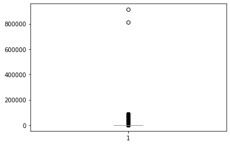

```python
# Quick box plot on duration in San Francisco
plt.boxplot(df_san_clean.duration_sec);
```

Looking at some basic definitions

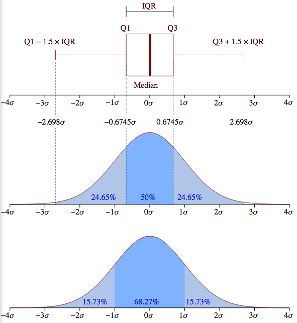

Having a large number of outliers shown in the box plot, it is reasonable to drop the outlier larger than Q3 + 1.5 x IQR Let us calculate this for this dataset

```python
# Calculating the quantiles the the top cut off duration_sec
df_san_clean_large_duration = df_san_clean.duration_sec.quantile([0.25,0.75])
df_san_clean_IRQ = df_san_clean_large_duration[0.75] - df_san_clean_large_duration[0.25]
time_top_cutoff = df_san_clean_large_duration[0.75] + 1.5 * df_san_clean_IRQ
print (time_top_cutoff)
```

```
1718.0
```

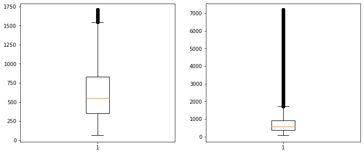

```python
# Quick box plot on duration for the to-be-trimmed dataset
# Plotting anything below the calculated threshold
plt.figure(figsize = [12, 5])
plt.subplot(1,2,1)
df_san_clean_small1 = df_san_clean[df_san_clean.duration_sec<=1707]
plt.boxplot(df_san_clean_small1.duration_sec);

# Plotting anything below an arbitrary number of 7200 seconds (2 hrs)
plt.subplot(1,2,2)
df_san_clean_small2 = df_san_clean[df_san_clean.duration_sec<=7200]
plt.boxplot(df_san_clean_small2.duration_sec);
```

Looking at this, I decided to go with the right box plot and keep all the entries under 2 hrs for the analyses. This way, our dataframe will not have too much outlier’s problem and at the same time we are not losing too much data and will capture the bulk of the trips

```python
# Getting a sense of data loss
a, b = (df_san_clean.duration_sec<=7200).sum(), (df_san_clean.duration_sec>7200).sum()

print('data loss is: ',100*b/a, ' %')
```

```
data loss is:  0.4060735401139967  %
```

```python
# Dropping enteries larger than 2 hrs
drop_index = df_san_clean[df_san_clean.duration_sec>7200].index
df_san_clean = df_san_clean.drop(drop_index)
```

```python
# Checking the data after dropping large durations
df_san_clean.describe()
```

|  | duration_sec |
| --- | --- |
| count | 2.863072e+06 |
| mean | 7.380391e+02 |
| std | 6.405247e+02 |
| min | 6.100000e+01 |
| 25% | 3.620000e+02 |
| 50% | 5.780000e+02 |
| 75% | 9.000000e+02 |
| max | 7.200000e+03 |

```python
df_san_clean.shape
```

```
(2863072, 8)
```

### The dataframe for San Francisco looks clean and nice; now we repeat the same procedure for Vancouver

```python
# Drop all the extra columns except `Duration (sec.)`, `Departure`, `Return`, `Membership type` for Vancouver for all months

col_keep =['Duration (sec.)', 'Departure','Return', 'Membership type']

for df in df_van:
    df = df.drop(df.columns.difference(col_keep), axis = 1, inplace = True)

df_van[0].head()
```

|  | Departure | Return | Membership type | Duration (sec.) |
| --- | --- | --- | --- | --- |
| 0 | 2/1/2019 0:00 | 2/1/2019 0:00 | 365 Standard | 177 |
| 1 | 2/1/2019 0:00 | 2/1/2019 0:00 | 365 Plus | 221 |
| 2 | 2/1/2019 0:00 | 2/1/2019 0:00 | Vancity Community Pass | 3272 |
| 3 | 2/1/2019 0:00 | 2/1/2019 0:00 | 365 Day Pass Plus SALE | 157 |
| 4 | 1/31/2019 23:00 | 2/1/2019 0:00 | 365 Day Pass Plus SALE | 516 |

```python
# Making the column names consistent with the other dataframe

for df in df_van:
    df = df.rename(columns={"Departure": "start_time", "Return": "end_time","Membership type": "user_type",
                           "Duration (sec.)":"duration_sec"}, inplace = True)
df_van[0].head()
```

|  | start_time | end_time | user_type | duration_sec |
| --- | --- | --- | --- | --- |
| 0 | 2/1/2019 0:00 | 2/1/2019 0:00 | 365 Standard | 177 |
| 1 | 2/1/2019 0:00 | 2/1/2019 0:00 | 365 Plus | 221 |
| 2 | 2/1/2019 0:00 | 2/1/2019 0:00 | Vancity Community Pass | 3272 |
| 3 | 2/1/2019 0:00 | 2/1/2019 0:00 | 365 Day Pass Plus SALE | 157 |
| 4 | 1/31/2019 23:00 | 2/1/2019 0:00 | 365 Day Pass Plus SALE | 516 |

```python
# Combine all months to one data frame for Vancouver
df_van_clean = pd.concat(df_van)

df_van_clean.shape
```

```
(1025125, 4)
```

```python
# Changing the datatype to datetime
df_van_clean['start_time']= pd.to_datetime(df_van_clean['start_time'])
#df_van_clean['end_time']= pd.to_datetime(df_van_clean['end_time'])

df_van_clean.info()
```

```
<class 'pandas.core.frame.DataFrame'>
Int64Index: 1025125 entries, 0 to 30723
Data columns (total 4 columns):
 #   Column        Non-Null Count    Dtype
---  ------        --------------    -----
 0   start_time    1025125 non-null  datetime64[ns]
 1   end_time      1025047 non-null  object
 2   user_type     966565 non-null   object
 3   duration_sec  1025125 non-null  int64
dtypes: datetime64[ns](1), int64(1), object(2)
memory usage: 39.1+ MB
```

```python
df_van_clean['end_time'].head()
```

```
0    2/1/2019 0:00
1    2/1/2019 0:00
2    2/1/2019 0:00
3    2/1/2019 0:00
4    2/1/2019 0:00
Name: end_time, dtype: object
```

```python
df_van_clean['start_time']
```

```
0       2019-02-01 00:00:00
1       2019-02-01 00:00:00
2       2019-02-01 00:00:00
3       2019-02-01 00:00:00
4       2019-01-31 23:00:00
                ...
30719   2020-04-01 06:00:00
30720   2020-04-01 05:00:00
30721   2020-04-01 04:00:00
30722   2020-04-01 02:00:00
30723   2020-04-01 00:00:00
Name: start_time, Length: 1025125, dtype: datetime64[ns]
```

```python
# Adding day of the week
# Python notation: Monday=0, Sunday=6.
df_van_clean['day_of_week'] = df_van_clean['start_time'].dt.dayofweek.astype('category')

# Adding Month of the year
# Python notation: January=1, December=12.
df_van_clean['month_of_year'] = df_van_clean['start_time'].dt.month.astype('category')

# Adding  year
df_van_clean['year'] = df_van_clean['start_time'].dt.year.astype('category')

df_van_clean.head()
```

|  | start_time | end_time | user_type | duration_sec | day_of_week | month_of_year | year |
| --- | --- | --- | --- | --- | --- | --- | --- |
| 0 | 2019-02-01 00:00:00 | 2/1/2019 0:00 | 365 Standard | 177 | 4 | 2 | 2019 |
| 1 | 2019-02-01 00:00:00 | 2/1/2019 0:00 | 365 Plus | 221 | 4 | 2 | 2019 |
| 2 | 2019-02-01 00:00:00 | 2/1/2019 0:00 | Vancity Community Pass | 3272 | 4 | 2 | 2019 |
| 3 | 2019-02-01 00:00:00 | 2/1/2019 0:00 | 365 Day Pass Plus SALE | 157 | 4 | 2 | 2019 |
| 4 | 2019-01-31 23:00:00 | 2/1/2019 0:00 | 365 Day Pass Plus SALE | 516 | 3 | 1 | 2019 |

```python
# Checking the finished data frame for Vancouver
df_van_clean.info()
```

```
<class 'pandas.core.frame.DataFrame'>
Int64Index: 1025125 entries, 0 to 30723
Data columns (total 7 columns):
 #   Column         Non-Null Count    Dtype
---  ------         --------------    -----
 0   start_time     1025125 non-null  datetime64[ns]
 1   end_time       1025047 non-null  object
 2   user_type      966565 non-null   object
 3   duration_sec   1025125 non-null  int64
 4   day_of_week    1025125 non-null  category
 5   month_of_year  1025125 non-null  category
 6   year           1025125 non-null  category
dtypes: category(3), datetime64[ns](1), int64(1), object(2)
memory usage: 42.0+ MB
```

```python
# Checking the finished data frame for Vancouver
df_san_clean.isnull().sum()
```

```
duration_sec     0
start_time       0
end_time         0
user_type        0
time_of_day      0
day_of_week      0
month_of_year    0
year             0
dtype: int64
```

```python
# Checking the finished data frame for Vancouver
df_van_clean.shape
```

```
(1025125, 7)
```

```python
# Checking the finished data frame for Vancouver
df_van_clean.nunique()
```

```
start_time       33577
end_time         33360
user_type           21
duration_sec     17062
day_of_week          7
month_of_year       12
year                 2
dtype: int64
```

```python
df_van_clean.describe()
```

|  | duration_sec |
| --- | --- |
| count | 1.025125e+06 |
| mean | 1.322027e+03 |
| std | 7.799517e+03 |
| min | 0.000000e+00 |
| 25% | 3.870000e+02 |
| 50% | 6.800000e+02 |
| 75% | 1.169000e+03 |
| max | 1.827789e+06 |

Like what we saw in San Francisco data, we see 0 for duration and very large value of 1.8e06 sec (507 hrs) for the duration which are worth investigation

Starting first with 0 second entries

```python
# Checking the 0 secons
df_van_clean[df_van_clean.duration_sec == 0]
```

|  | start_time | end_time | user_type | duration_sec | day_of_week | month_of_year | year |
| --- | --- | --- | --- | --- | --- | --- | --- |
| 479 | 2019-01-31 17:00:00 | NaN | NaN | 0 | 3 | 1 | 2019 |
| 2393 | 2019-01-30 10:00:00 | 1/31/2019 17:00 | 365 Day Pass Standard SALE | 0 | 2 | 1 | 2019 |
| 2408 | 2019-01-30 10:00:00 | 1/30/2019 18:00 | 365 Day Founding Plus | 0 | 2 | 1 | 2019 |
| 2437 | 2019-01-30 10:00:00 | 1/30/2019 11:00 | 365 Day Founding Plus | 0 | 2 | 1 | 2019 |
| 2482 | 2019-01-30 09:00:00 | 1/30/2019 11:00 | 365 Day Founding Plus | 0 | 2 | 1 | 2019 |
| ... | ... | ... | ... | ... | ... | ... | ... |
| 2878 | 2020-04-27 21:00:00 | NaN | NaN | 0 | 0 | 4 | 2020 |
| 8909 | 2020-04-21 21:00:00 | 2020-04-29 10:00 | 30 Day Pass | 0 | 1 | 4 | 2020 |
| 9344 | 2020-04-21 16:00:00 | 2020-04-24 15:00 | VIP | 0 | 1 | 4 | 2020 |
| 13820 | 2020-04-18 10:00:00 | 2020-04-18 15:00 | 365 Corporate Standard | 0 | 5 | 4 | 2020 |
| 22008 | 2020-04-10 23:00:00 | 2020-04-11 9:00 | 365 Plus | 0 | 4 | 4 | 2020 |

291 rows × 7 columns

We can go ahead and drop all the rows with 0 sec for duration however since we put the low threshold of 60 seconds for San Francisco, we will use this number to cut the small numbers

```python
# Dropping below 60 second rows
drop_ind = df_van_clean[df_van_clean.duration_sec <=60].index
df_van_clean = df_van_clean.drop(drop_ind)
df_van_clean.describe()
```

|  | duration_sec |
| --- | --- |
| count | 7.712080e+05 |
| mean | 1.360511e+03 |
| std | 8.094284e+03 |
| min | 6.100000e+01 |
| 25% | 4.090000e+02 |
| 50% | 7.020000e+02 |
| 75% | 1.193000e+03 |
| max | 1.827789e+06 |

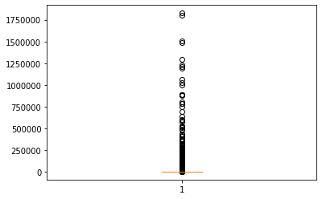

```python
# Quick box plot on duration for Vancouver
plt.boxplot(df_van_clean.duration_sec);
```

```python
# Calculating the quantiles for the top cut off duration_sec
df_van_clean_large_duration = df_van_clean.duration_sec.quantile([0.25,0.75])
df_van_clean_IRQ = df_van_clean_large_duration[0.75] - df_van_clean_large_duration[0.25]
time_top_cutoff = df_van_clean_large_duration[0.75] + 1.5 * df_van_clean_IRQ
print (time_top_cutoff)
```

```
2369.0
```

This database has the same problem as San Francisco dataset so we can apply the same procedure to this as well

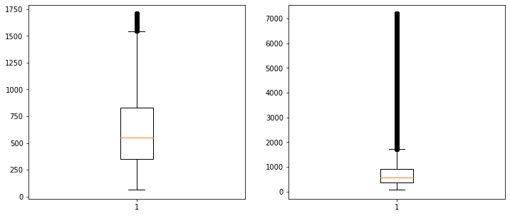

```python
# Quick box plot on duration for the to-be-trimmed dataset
# Plotting anything below the calculated threshold
plt.figure(figsize = [12, 5])
plt.subplot(1,2,1)
df_van_clean_small1 = df_van_clean[df_van_clean.duration_sec<=2306]
plt.boxplot(df_san_clean_small1.duration_sec);

# Plotting anything below an arbitrary number of 7200 seconds (2 hrs)
plt.subplot(1,2,2)
df_san_clean_small2 = df_san_clean[df_san_clean.duration_sec<=7200]
plt.boxplot(df_san_clean_small2.duration_sec);
```

```python
# Getting a sense of data loss
a, b = (df_van_clean.duration_sec<=7200).sum(), (df_van_clean.duration_sec>7200).sum()

print('data loss is: ',100*b/a, ' %')
```

```
data loss is:  1.4041542137117717  %
```

```python
# Dropping enteries larger than 2 hrs
drop_index = df_van_clean[df_van_clean.duration_sec>7200].index
df_van_clean = df_van_clean.drop(drop_index)
```

```python
# Checking the data after dropping large durations
df_van_clean.describe()
```

|  | duration_sec |
| --- | --- |
| count | 669287.000000 |
| mean | 969.385401 |
| std | 942.042704 |
| min | 61.000000 |
| 25% | 406.000000 |
| 50% | 694.000000 |
| 75% | 1166.000000 |
| max | 7200.000000 |

```python
df_van_clean.shape
```

```
(669287, 7)
```

## Storing Data

```python
# Storing the cleaned data frames as CSV
df_van_clean.to_csv('df_van_clean.csv',index=False)
df_san_clean.to_csv('df_san_clean.csv',index=False)
```

## Visualizing Data

### What is the structure of your dataset?

> There are 2.9 millions entries in the San Francisco data base with 8 features (`duration_sec`, `start_time`, `end_time`, `user_type`, `time_of_day`, `day_of_week`, `month_of_year` and `year`) and 0.7 million entries in the Vancouver data base with 7 features similar to the features of San Francisco except `time_of_day` as we could not extract this from the available data.

> the `start_time`, `end_time` are datetime type, `duration_sec` is numerical, and the rest are categorical features.

### What is/are the main feature(s) of interest in your dataset?

> The main features of interest are `time_of_day`, `day_of_week`, or `month_of_year` and `year` to explore the user's behavior. We are also interested in `duration_sec` to check how long the trips took and `user_type` to see if there was any dependency on the user membership.

> Since we are also interested in the possible change due to COVID-19 in 2020, we will be also looking into yearly changes in some of these features

### What features in the dataset do you think will help support your investigation into your feature(s) of interest?

> All above could be equally important, and we would need to explore and find out the relations. One particular matter is the effect of the pandemic into bike usages which will come out when we do yearly comparison

## Univariate Exploration

> Let's start with the ride duration

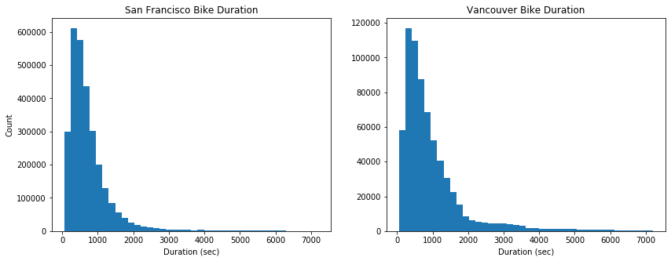

```python
plt.figure(figsize = [14, 5])
plt.subplot(1,2,1)
plt.hist(df_san_clean.duration_sec, bins = 40)
plt.title('San Francisco Bike Duration')
plt.xlabel('Duration (sec)')
plt.ylabel('Count')

plt.subplot(1,2,2)
plt.hist(df_van_clean.duration_sec, bins = 40)
plt.title('Vancouver Bike Duration')
plt.xlabel('Duration (sec)');
```

It looks both cities have right skewed distribution. This suggests that axis transformation might be helpful

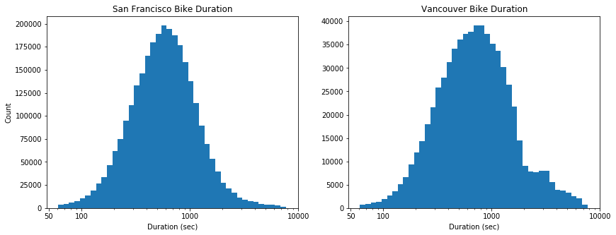

```python
# Replotting above with axis transformation
plt.figure(figsize = [14, 5])
plt.subplot(1,2,1)
san_bin = 10**np.arange(1.785330, np.log10(df_san_clean.duration_sec.max()) + 0.05, 0.05)
#plt.figure(figsize=[8, 5])
plt.title('San Francisco Bike Duration')
plt.hist(data = df_san_clean, x = 'duration_sec', bins = san_bin)
plt.xscale('log')
plt.xticks([50, 100, 1000, 10000], ['50', '100', '1000', '10000'])
plt.xlabel('Duration (sec)')
plt.ylabel('Count');

plt.subplot(1,2,2)
van_bin = 10**np.arange(1.785330, np.log10(df_van_clean.duration_sec.max()) + 0.05, 0.05)
#plt.figure(figsize=[8, 5])
plt.title('Vancouver Bike Duration')
plt.hist(data = df_van_clean, x = 'duration_sec', bins = van_bin)
plt.xscale('log')
plt.xticks([50, 100, 1000, 10000], ['50', '100', '1000', '10000'])
plt.xlabel('Duration (sec)');
```

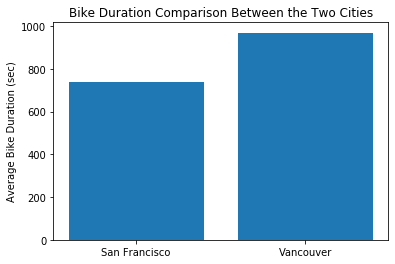

```python
# Comparing the average bike time between the two cities
san_ride_time_mean = df_san_clean.duration_sec.mean()
van_ride_time_mean = df_van_clean.duration_sec.mean()
plt.title('Bike Duration Comparison Between the Two Cities')
plt.bar(x= ['San Francisco','Vancouver'], height = [san_ride_time_mean,van_ride_time_mean]);
plt.ylabel('Average Bike Duration (sec)');
```

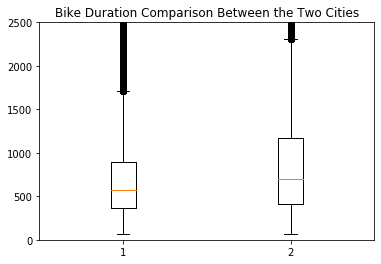

```python
data = [df_san_clean.duration_sec, df_van_clean.duration_sec]
fig1, ax1 = plt.subplots()
ax1.set_title('Bike Duration Comparison Between the Two Cities')
ax1.boxplot(data)
plt.ylim(0, 2500)
plt.show()
```

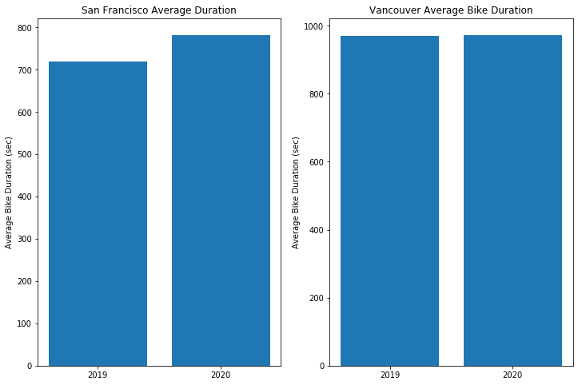

```python
# Comparing the average ridership between 2019 and 2020
san_ride_time_mean_2019 = df_san_clean[df_san_clean.year == 2019].duration_sec.mean()
san_ride_time_mean_2020 = df_san_clean[df_san_clean.year == 2020].duration_sec.mean()

van_ride_time_mean_2019 = df_van_clean[df_van_clean.year == 2019].duration_sec.mean()
van_ride_time_mean_2020 = df_van_clean[df_van_clean.year == 2020].duration_sec.mean()

plt.figure(figsize = [12,8])
plt.subplot(1,2,1)
plt.bar(x= ['2019','2020'], height = [san_ride_time_mean_2019,san_ride_time_mean_2020]);
plt.ylabel('Average Bike Duration (sec)');
plt.title('San Francisco Average Duration')

plt.subplot(1,2,2)
plt.bar(x= ['2019','2020'], height = [van_ride_time_mean_2019,van_ride_time_mean_2020]);
plt.ylabel('Average Bike Duration (sec)');
plt.title('Vancouver Average Bike Duration');
```

### Discuss the distribution(s) of your variable(s) of interest. Were there any unusual points? Did you need to perform any transformations?

> Looking at the `duration_sec`, both data sets appear to be highly right skewed which suggested that a log x-scale transformation might be helpful. Performing the log10 scale transformation shows that the distribution for both are Log-normal. This is helpful to know for the case where we would need to do modelling and prediction, however that is not the intent here

### Of the features you investigated, were there any unusual distributions? Did you perform any operations on the data to tidy, adjust, or change the form of the data? If so, why did you do this?

> When comparing the data between the two cities, it appears that San Francisco has higher number of rides which is normal given the population difference between the two cities. However, it appears that the Vancouver riders were using the bikes for longer duration in average.

> The other interesting finding is that the average ride duration remained relatively constant for Vancouver from 2019 to 2020 with a slight increase. However, San Francisco showed a more significant increase in average ride duration in 2020.

## Bivariate Exploration

> One of the more straightforward factors to look at is the average bike duration for the day of the week, so let's have a look at this

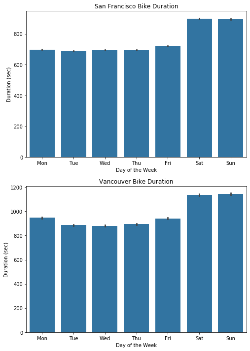

```python
# Bike duration for day of the week
fig, ax = plt.subplots(nrows=2, figsize = [8,12])

default_color = sb.color_palette()[0]
week_day_labels = ['Mon','Tue','Wed','Thu','Fri','Sat','Sun']

sb.barplot(x="day_of_week", y="duration_sec", data=df_san_clean, color=default_color, ax = ax[0])
ax[0].set_title('San Francisco Bike Duration')
ax[0].set_xticklabels(week_day_labels)
ax[0].set_xlabel('Day of the Week')
ax[0].set_ylabel('Duration (sec)');

sb.barplot(x="day_of_week", y="duration_sec", data=df_van_clean, color=default_color, ax = ax[1])
ax[1].set_title('Vancouver Bike Duration')
ax[1].set_xticklabels(week_day_labels)
ax[1].set_xlabel('Day of the Week')
ax[1].set_ylabel('Duration (sec)');
```

The above bar charts are interesting. for both cases, it seems people went for slightly longer ride in the weekends. While San Francisco riders kept the weekday rides essentially uniform, Vancouver riders seem to bump up the rides duration on Mondays and Fridays slightly.

We can next look into monthly trip duration distribution

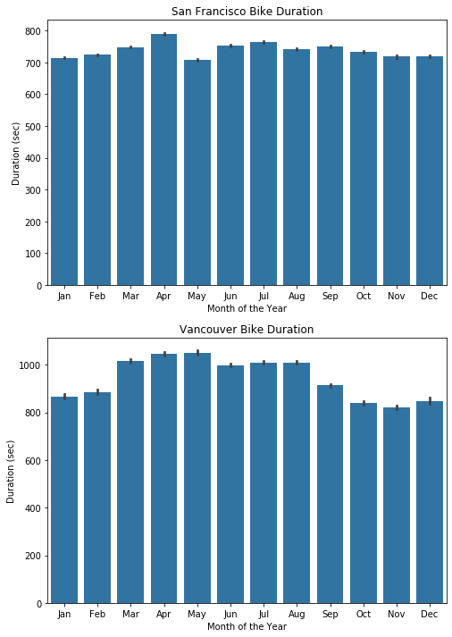

```python
# Bike duration for month of the year
fig, ax = plt.subplots(nrows=2, figsize = [8,12])

default_color = sb.color_palette()[0]
months_labels = ['Jan','Feb','Mar','Apr','May','Jun','Jul','Aug','Sep','Oct','Nov','Dec']

sb.barplot(x="month_of_year", y="duration_sec", data=df_san_clean, color=default_color, ax = ax[0])
ax[0].set_title('San Francisco Bike Duration')
ax[0].set_xticklabels(months_labels)
ax[0].set_xlabel('Month of the Year')
ax[0].set_ylabel('Duration (sec)');

sb.barplot(x="month_of_year", y="duration_sec", data=df_van_clean, color=default_color, ax = ax[1])
ax[1].set_title('Vancouver Bike Duration')
ax[1].set_xticklabels(months_labels)
ax[1].set_xlabel('Month of the Year')
ax[1].set_ylabel('Duration (sec)');
```

As expected, the summer months tend to show more bike rides. The peak for Vancouver is much more dominant than that in San Francisco and the reason could be the difference in the climates between the two cities. We now investigate when in the day most of the trips are taken place. As stated above, we do not have this data for Vancouver, so we only look into San Francisco for this.

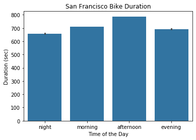

```python
# Plotting trips duration per time of the day for San Francisco
df_san_clean.head()

default_color = sb.color_palette()[0]

sb.barplot(x="time_of_day", y="duration_sec", data=df_san_clean, color=default_color)
plt.title('San Francisco Bike Duration')
plt.xlabel('Time of the Day')
plt.ylabel('Duration (sec)');
```

It seems most of the biking happens in the afternoon in San Francisco

Now we look at the differences between the users subscription which we look at the two dataset independently since Vancouver data is different and has many features

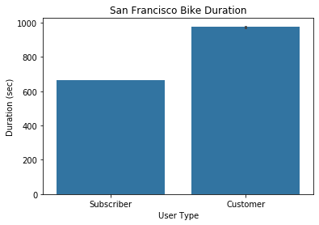

```python
# Bike duration per user type for San Francisco
sb.barplot(x="user_type", y="duration_sec", data=df_san_clean, color=default_color)
plt.title('San Francisco Bike Duration')
plt.xlabel('User Type')
plt.ylabel('Duration (sec)');
```

The non-subscribers (labeled as Customer here) are going for longer rides in San Francisco.

Let's have a peek into Vancouver

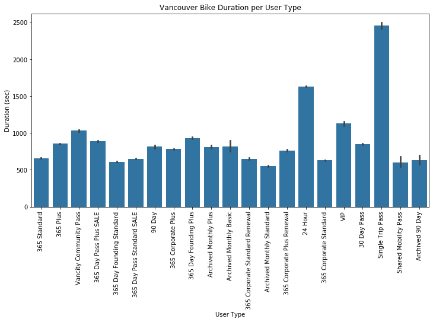

```python
# Bike duration per user type for Vancouver
plt.figure(figsize = [12,6])
sb.barplot(x="user_type", y="duration_sec", data=df_van_clean, color=default_color)
plt.title('Vancouver Bike Duration per User Type')
plt.xlabel('User Type')
plt.xticks(rotation=90)
plt.ylabel('Duration (sec)');
```

Now we look at some of categorial variables relations First we look at the user type for San Francisco

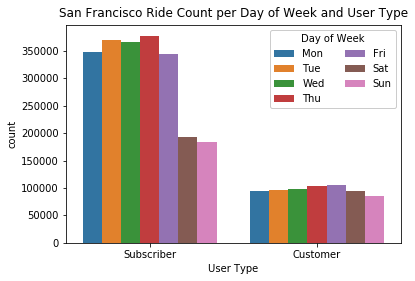

```python
# Customer type relation with day of week for San Francisco
ax = sb.countplot(data = df_san_clean, x = 'user_type', hue = 'day_of_week')
ax.legend(week_day_labels, loc = 1, ncol =2, framealpha = 1, title = 'Day of Week');
plt.title('San Francisco Ride Count per Day of Week and User Type', y = 1.01);
plt.xlabel('User Type');
```

Interestingly customers are accounted for less numbers despite traveling for longer period as we saw above The subscribers however are more frequent despite traveling less time as we saw above.

The subscribers also seem to use the bikes in the week days more often than the weekends

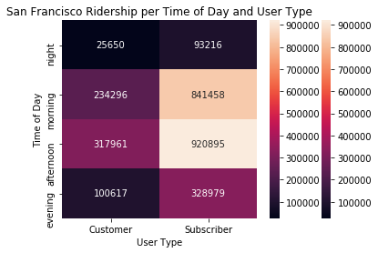

```python
# Use of heat map to see the relation between time of the day and subsciption type in San Francisco
ct_counts = df_san_clean.groupby(['user_type', 'time_of_day']).size()
ct_counts = ct_counts.reset_index()
ct_counts = ct_counts.rename(columns = {0:'count'})
ct_counts = ct_counts.pivot(index = 'time_of_day', columns = 'user_type', values = 'count')
sb.heatmap(ct_counts)
sb.heatmap(ct_counts, annot = True, fmt = 'd');
plt.xlabel('User Type')
plt.title('San Francisco Ridership per Time of Day and User Type', y = 1.01);
plt.ylabel('Time of Day');
```

The heatmap above shows the use of the bikes in San Francisco peaked in the morning and afternoon and it was significantly higher with the subscribers

We now look into Vancouver

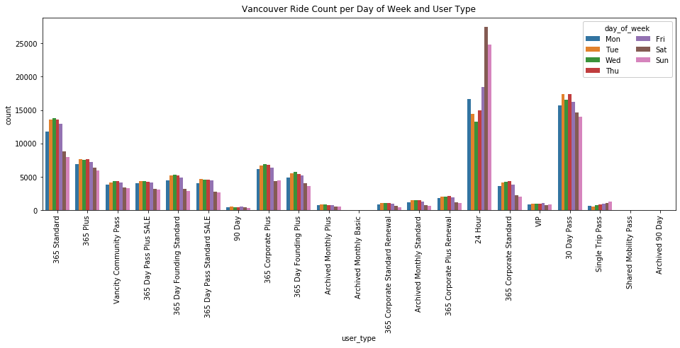

```python
# Customer type relation with day of week for San Vancouver
plt.figure(figsize = [16,5])
sb.countplot(data = df_van_clean, x = 'user_type', hue = 'day_of_week')
plt.legend(week_day_labels, loc = 1, ncol =2, framealpha = 1, title = 'day_of_week');
plt.title('Vancouver Ride Count per Day of Week and User Type', y = 1.01);
plt.xticks(rotation=90);
```

In Vancouver the user type labeled as `24 Hour` seem to have the highest count where user types `Archived Monthly Basic` , `Shared Mobility Pass` and `Archived 90 Day` appear to not have been used. This seems lack of data in dataset for these 3 features.

Let's now look into customer type relation with month of year for San Francisco

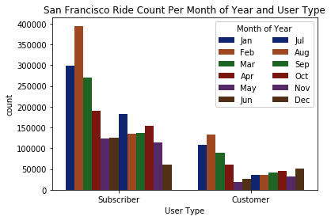

```python
# Customer type relation with month of year for San Francisco
ax = sb.countplot(data = df_san_clean, x = 'user_type', hue = 'month_of_year', palette = sb.color_palette("dark", 6))
ax.legend(months_labels, loc = 1, ncol =2, framealpha = 1, title = 'Month of Year');
plt.title('San Francisco Ride Count Per Month of Year and User Type')
plt.xlabel('User Type');
```

It appears both Subscribers and Customers have used the bike service in the first 4 months more often in San Francisco however this is due to having more data for those 4 month that include both 2019 and 2020 years so we cannot conclude anything concrete from this plot

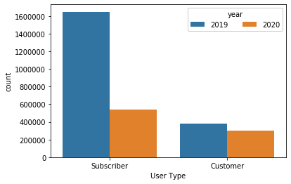

```python
# Customer type relation with year for San Francisco
ax = sb.countplot(data = df_san_clean, x = 'user_type', hue = 'year')
ax.legend(['2019','2020'], loc = 1, ncol =2, framealpha = 1, title = 'year');
plt.xlabel('User Type');
```

Yearly comparison of the subscribers and customers shows a decline in 2020 for San Francisco. This is expected as the data for 2020 is not for full year and the counts are less

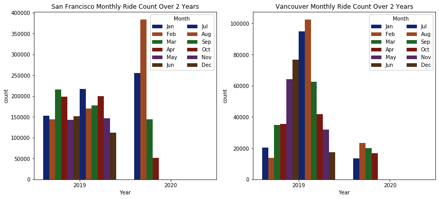

```python
# Monthly relation with year
plt.figure(figsize = [14,6])
plt.subplot(1,2,1)
ax = sb.countplot(data = df_san_clean, x = 'year', hue = 'month_of_year', palette = sb.color_palette("dark", 6))
ax.legend(months_labels, loc = 1, ncol =2, framealpha = 1, title = 'Month');
ax.set_title('San Francisco Monthly Ride Count Over 2 Years')
plt.xlabel('Year');

plt.subplot(1,2,2)
ax = sb.countplot(data = df_van_clean, x = 'year', hue = 'month_of_year', palette = sb.color_palette("dark", 6))
ax.legend(months_labels, loc = 1, ncol =2, framealpha = 1, title = 'Month');
ax.set_title('Vancouver Monthly Ride Count Over 2 Years');
plt.xlabel('Year');
```

Looking at the number of trips in different months and comparing them between 2019 and 2020 for San Francisco and Vancouver shows that in Vancouver there were many more trips that took place in the dry months however this distribution is generally flat for San Francisco in 2019.

This also shows in San Francisco the riders used the shared bikes more often in the first 4 months of 2020 while Vancouver data doesn't show much of a change for the first 4 months of the year

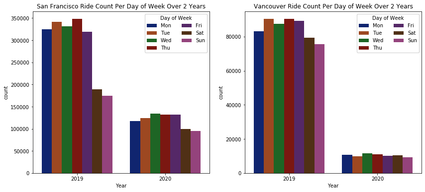

```python
# Daily relation with year
plt.figure(figsize = [14,6])
plt.subplot(1,2,1)
ax = sb.countplot(data = df_san_clean, x = 'year', hue = 'day_of_week', palette = sb.color_palette("dark", 7))
ax.legend(week_day_labels, loc = 1, ncol =2, framealpha = 1, title = 'Day of Week');
ax.set_title('San Francisco Ride Count Per Day of Week Over 2 Years')
plt.xlabel('Year');

plt.subplot(1,2,2)
ax = sb.countplot(data = df_van_clean, x = 'year', hue = 'day_of_week', palette = sb.color_palette("dark", 7))
ax.legend(week_day_labels, loc = 1, ncol =2, framealpha = 1, title = 'Day of Week');
ax.set_title('Vancouver Ride Count Per Day of Week Over 2 Years');
plt.xlabel('Year');
```

### Talk about some of the relationships you observed in this part of the investigation. How did the feature(s) of interest vary with other features in the dataset?

> There are several observations from the plots seen above
> 1. In both cities the duration of the rides was greater in the weekend and in general Vancouverite took longer rides
> 2. The duration of the rides are fairly even for San Franciscan throughout the year, but Vancouverite seem to ride longer in the dry season. Given the rainy nature of City of Vancouver, this is an expected trend
> 3. San Franciscan tend to have longer trips during the afternoon hours and customers tend to go for longer trips than the subscribers in this city
> 4. Vancouver has a much more complex pass structure than San Francisco and the single trip pass holders tend to go for longer rides in Vancouver.

### Did you observe any interesting relationships between the other features (not the main feature(s) of interest)?

> 1. Despite the `customer` membership types going for longer rides in San Francisco they account for much smaller number of trips
> 2. In San Francisco Jan, Feb, and Mar account for the highest number of the trips with Feb being the most popular time to ride
> 3. San Francisco data also shows a very large drop in use of the bikes for subscribers in 2020 where the customer type usage does not seem to have changed much from 2019 to 2020. This is due to less data collection in 2020
> 4. First 4 months of 2020 shows an increase in using the bikes in general in San Francisco however there is not any major change in 2020 usage in Vancouver.
> 5. San Francisco data also shows a major drop in the number of bike rides in the weekends for 2019; however, this drop is less pronounced in 2020. The lower height of the bars for 2020 is due to less data collection since we only have the data for the first 4 months of 2020.

## Multivariate Exploration

> It is a good idea to take a look at the distribution tabulated based on the time of the day and day of week

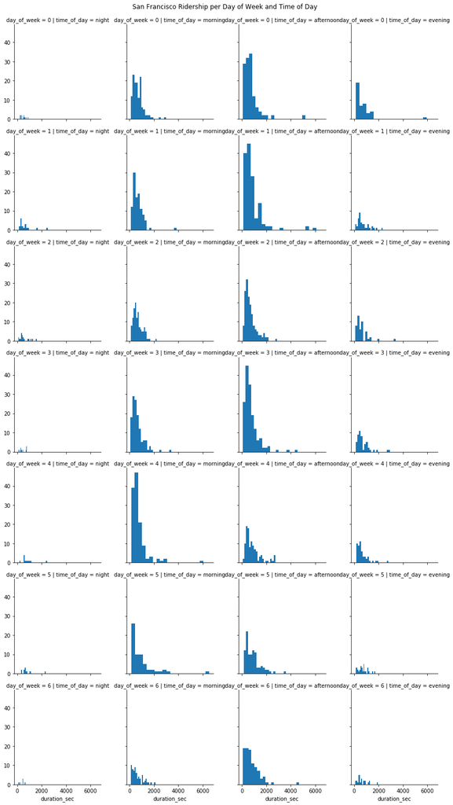

```python
# Plotting the histograms for San Francisco per time of day and day of week
samples = np.random.choice(df_san_clean.shape[0], 2000, replace = False)
san_samp = df_san_clean.iloc[samples]

plt.figure(figsize = [16, 10]);
g = sb.FacetGrid(san_samp, col="time_of_day", row="day_of_week");
g = g.map(plt.hist, "duration_sec", bins = 20);
g.fig.suptitle('San Francisco Ridership per Day of Week and Time of Day', y = 1.01)
plt.show();
```

San Francisco histograms chart above shows that most of the trips were more or less in the window below 2000 seconds regardless of the day of week and the time of day

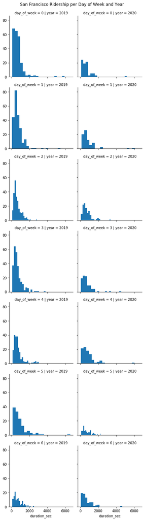

```python
# Plotting the histograms for San Francisco per year and day of week
plt.figure(figsize = [16, 10]);
g = sb.FacetGrid(san_samp, col="year", row="day_of_week");
g = g.map(plt.hist, "duration_sec", bins = 20);
g.fig.suptitle('San Francisco Ridership per Day of Week and Year', y = 1.01)
plt.show();
```

No new revelation here, most trips seem to be under 2000 seconds

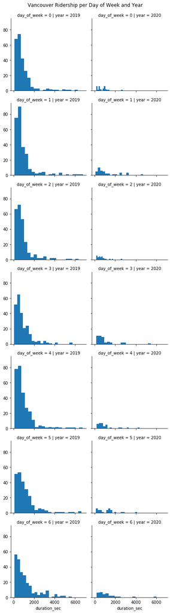

```python
# Plotting the histograms for Vancouver
samples = np.random.choice(df_van_clean.shape[0], 2000, replace = False)
van_samp = df_van_clean.iloc[samples]

plt.figure(figsize = [16, 10])
g = sb.FacetGrid(van_samp, col="year", row="day_of_week")
g = g.map(plt.hist, "duration_sec", bins = 20)
g.fig.suptitle('Vancouver Ridership per Day of Week and Year', y = 1.01)
plt.show();
```

In Vancouver, the window of the duration is a bit larger and can be called to be mostly below 4000 seconds mark

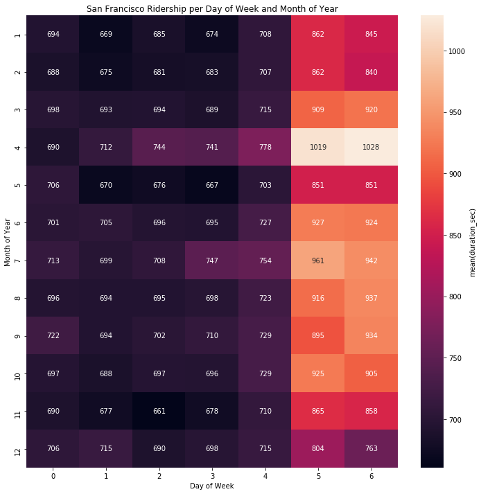

```python
# Plotting the heatmap to put ridership per day of week and month of year together for San Francisco
plt.figure(figsize = [12,12])
cat_means = df_san_clean.groupby(['day_of_week', 'month_of_year']).mean()['duration_sec']
cat_means = cat_means.reset_index(name = 'duration_sec_avg')
cat_means = cat_means.pivot(index = 'month_of_year', columns = 'day_of_week',
                            values = 'duration_sec_avg')
sb.heatmap(cat_means, annot = True, fmt = '.0f',cbar_kws = {'label' : 'mean(duration_sec)'})
plt.xlabel('Day of Week');
plt.ylabel('Month of Year');
plt.title('San Francisco Ridership per Day of Week and Month of Year', y = 1.01);
```

The heatmap above shows the same information we found earlier for San Francisco as below

- More or less even ride time distribution for the weekdays throughout the season
- Significant increase in the duration for the weekend
- The longest trips takes place in Saturday and Sunday of April

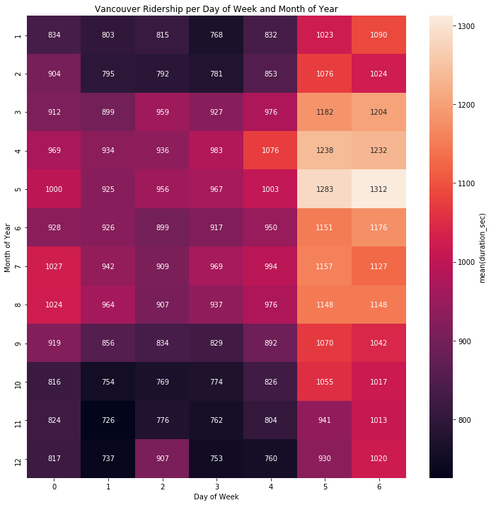

```python
# Plotting the heatmap to put ridership per day of week and month of year together for Vancouver
plt.figure(figsize = [12,12])
cat_means = df_van_clean.groupby(['day_of_week', 'month_of_year']).mean()['duration_sec']
cat_means = cat_means.reset_index(name = 'duration_sec_avg')
cat_means = cat_means.pivot(index = 'month_of_year', columns = 'day_of_week',
                            values = 'duration_sec_avg')
sb.heatmap(cat_means, annot = True, fmt = '.0f',cbar_kws = {'label' : 'mean(duration_sec)'})
plt.xlabel('Day of Week');
plt.ylabel('Month of Year');
plt.title('Vancouver Ridership per Day of Week and Month of Year', y = 1.01);
```

Similarly, same information as we discovered earlier on Vancouver

- The ride time is less evenly distributed for the weekdays throughout the season and tends to climb in dry months
- Increase in the duration for the weekend but perhaps less pronounced jump when compared to San Francisco
- Longest trips take place in Saturday and Sunday of May

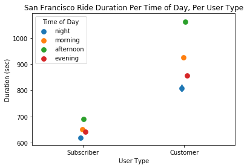

```python
# Plotting the user type vs duration and time of day for San Francisco
ax = sb.pointplot(data = df_san_clean, x = 'user_type', y = 'duration_sec', hue = 'time_of_day', dodge = 0.05, linestyles = "");
ax.set_title('San Francisco Ride Duration Per Time of Day, Per User Type');
plt.xlabel('User Type');
ax.legend(title = 'Time of Day')
plt.ylabel('Duration (sec)');
```

One interesting outcome of the plot above is higher variance in duration for the Customer user types when we look at the time of day. The subscribers seem to be more consistent with the duration and this could be due to using the bikes for cummute to work

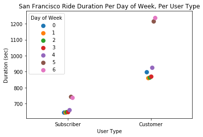

```python
# Plotting the user type vs duration and time of day for San Francisco
ax = sb.pointplot(data = df_san_clean, x = 'user_type', y = 'duration_sec', hue = 'day_of_week', dodge = 0.1, linestyles = "");
ax.set_title('San Francisco Ride Duration Per Day of Week, Per User Type')
ax.legend(title = 'Day of Week',loc='upper left')
plt.xlabel('User Type');
plt.ylabel('Duration (sec)');
```

Similar trend as above is shown when we look at the ride duration per day in week for different user types in San Francisco

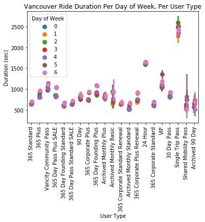

```python
# Plotting the user type vs duration and time of day for Vancouver
ax = sb.pointplot(data = df_van_clean, x = 'user_type', y = 'duration_sec', hue = 'day_of_week', dodge = 0.1, linestyles = "");
ax.set_title('Vancouver Ride Duration Per Day of Week, Per User Type')
ax.legend(title = 'Day of Week',loc='upper left')
plt.xticks(rotation=90);
plt.xlabel('User Type');
plt.ylabel('Duration (sec)');
```

Not whole alot to see above. the weekday rides are generally clumped together so are the weekend rides. Also the weekly variance in ride duration seems to be larger for single trip pass holders in Vancouver

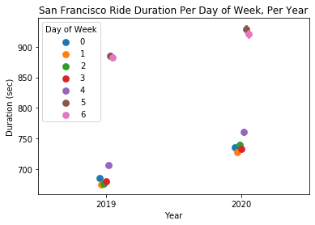

```python
# Plotting the year vs duration and time of day for San Francisco
ax = sb.pointplot(data = df_san_clean, x = 'year', y = 'duration_sec', hue = 'day_of_week', dodge = 0.1, linestyles = "");
ax.set_title('San Francisco Ride Duration Per Day of Week, Per Year')
ax.legend(title = 'Day of Week',loc='upper left')
plt.xlabel('Year');
plt.ylabel('Duration (sec)');
```

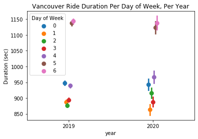

```python
# Plotting the year vs duration and time of day for Vancouver
ax = sb.pointplot(data = df_van_clean, x = 'year', y = 'duration_sec', hue = 'day_of_week', dodge = 0.1, linestyles = "");
ax.set_title('Vancouver Ride Duration Per Day of Week, Per Year')
ax.legend(title = 'Day of Week',loc='upper left')
plt.ylabel('Duration (sec)');
```

The top two plots narrate the same pattern we saw before by showing the weekend ride duration are generally longer and in 2020 the riders went for longer rides in San Francisco. One small finding here is the level of variance in Vancouver riders which seems to be high in 2020 weekday rides

### Talk about some of the relationships you observed in this part of the investigation. Were there features that strengthened each other in terms of looking at your feature(s) of interest?

> Plotting the histograms table shows that regardless of what year, month, or day of week, majority of the trips were under 2000 seconds in San Francisco while the trips in Vancouver tend to stretch into 4000 seconds mark.

> Another finding is that the non-subscriber/member user types seem to have a larger variance in the trip duration for both cities while the subscribers tend to go for more consistent ride duration which might mean they probably use it for some fixed trip length such as commute to work and back

### Were there any interesting or surprising interactions between features?

> The non-members riding on the weekends tend to go for the longest trips, especially in San Francisco.